# Tugas Pertemuan 5 MPDW

Radhitya Harma

2023-09-26

## Library / Packages

*Package* R yang akan digunakan pada perkuliahan Analisis Deret Waktu sesi UTS adalah: `forecast`, `graphics`, `TTR`, `TSA` . Jika *package* tersebut belum ada, silakan install terlebih dahulu.

```r
library(ggplot2)
library(tsibble) #bikin tabel
library(tseries)
library(MASS) #uji stasioneritas ragam
```

Jika sudah ada, silakan panggil library *package* tersebut.

```r
library("forecast")
library("graphics")
library("TTR")
library("TSA")
```

## Impor Data

```r
#install.packages("rio") #install jika belum ada
library(rio)
databaru <- import("https://raw.githubusercontent.com/RadhityaHarma12/MPDW/main/Pertemuan%205/databaru.csv")
databaru
```

```
##     periode      x
## 1         1  97907
## 2         2 136954
## 3         3 141112
## 4         4 128263
## 5         5 135960
## 6         6 119400
## 7         7  95011
## 8         8  91423
## 9         9 113009
## 10       10 100552
## 11       11  89003
## 12       12  94061
## 13       13  78078
## 14       14  89697
```

[output cut: 106 more lines]

```r
str(databaru)
```

```
## 'data.frame':    120 obs. of  2 variables:
##  $ periode: int  1 2 3 4 5 6 7 8 9 10 ...
##  $ x      : int  97907 136954 141112 128263 135960 119400 95011 91423 113009 100552 ...
```

```r
dim(databaru)
```

```
## [1] 120   2
```

## Data Penuh

### Time Series

Mengubah data agar terbaca sebagai data deret waktu dengan fungsi `ts()` .

```r
databaru.ts <- ts(databaru$x)
```

Menampilkan ringkasan data

```r
summary(databaru.ts)
```

```
##    Min. 1st Qu.  Median    Mean 3rd Qu.    Max.
##   78078  121592  198502  239331  304183  649089
```

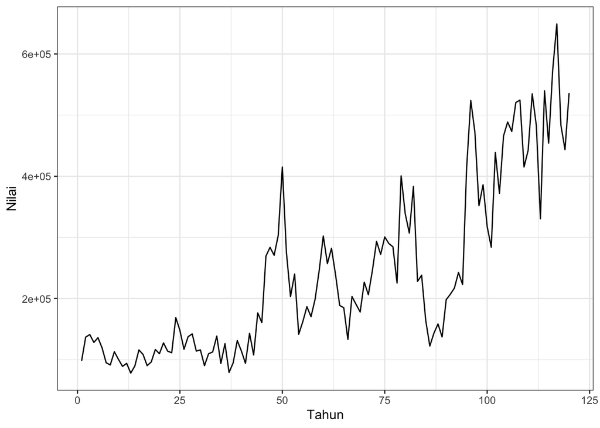

```r
plot_databaru <- databaru.ts |> as_tsibble() |>
  ggplot(aes(x = databaru$periode, y = databaru$x)) + geom_line() + theme_bw() +
  xlab("Tahun") + ylab("Nilai")
plot_databaru
```

```r
mean(databaru.ts)
```

```
## [1] 239330.6
```

### Plot ACF

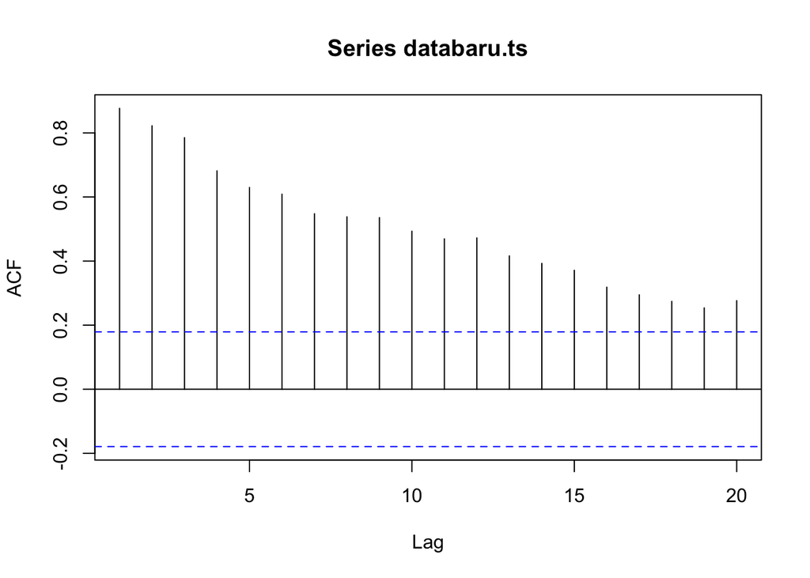

```r
acf(databaru.ts)
```

Berdasarkan plot ACF, terlihat bahwa plot ACF pada data tersebut cenderung *tails off* slowly maka data tersebut terindikasi tidak stasioner

### Uji ADF

```r
tseries::adf.test(databaru.ts, k=6)
```

```
##
##  Augmented Dickey-Fuller Test
##
## data:  databaru.ts
## Dickey-Fuller = -3.0721, Lag order = 6, p-value = 0.1313
## alternative hypothesis: stationary
```

$H_0$ : Data tidak stasioner dalam rataan

$H_1$ : Data stasioner dalam rataan

Berdasarkan uji ADF tersebut, didapat *p-value* sebesar 0.1313 yang lebih besar dari taraf nyata 5% sehingga terima $H_0$ dan menandakan bahwa data tidak stasioner dalam rataan. Hal ini sesuai dengan hasil eksplorasi menggunakan plot time series dan plot ACF.

### Plot Box-Cox

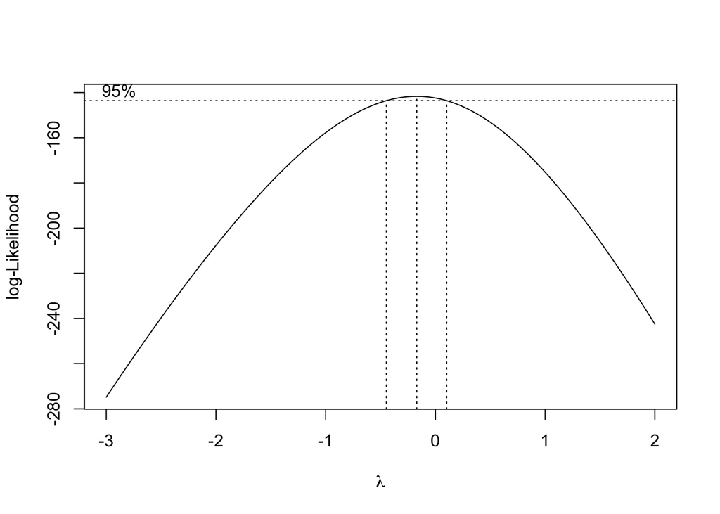

```r
index <- seq(1:120) #sebanyak row data
bc = boxcox(databaru.ts~index, lambda = seq(-3,2,by=0.01))
```

```r
#Nilai Rounded Lambda
lambda <- bc$x[which.max(bc$y)]
lambda
```

```
## [1] -0.17
```

```r
#SK
bc$x[bc$y > max(bc$y) - 1/2 * qchisq(.95,1)]
```

```
##  [1] -0.44 -0.43 -0.42 -0.41 -0.40 -0.39 -0.38 -0.37 -0.36 -0.35 -0.34 -0.33
## [13] -0.32 -0.31 -0.30 -0.29 -0.28 -0.27 -0.26 -0.25 -0.24 -0.23 -0.22 -0.21
## [25] -0.20 -0.19 -0.18 -0.17 -0.16 -0.15 -0.14 -0.13 -0.12 -0.11 -0.10 -0.09
## [37] -0.08 -0.07 -0.06 -0.05 -0.04 -0.03 -0.02 -0.01  0.00  0.01  0.02  0.03
## [49]  0.04  0.05  0.06  0.07  0.08  0.09  0.10
```

Gambar di atas menunjukkan nilai *rounded value* ($\lambda$) optimum sebesar **-0,17** dan pada selang kepercayaan 95% nilai memiliki batas bawah **-0,44** dan batas atas **0,10**. Selang tersebut tidak memuat nilai 1 sehingga dapat dikatakan bahwa data tersebut **tidak stasioner dalam ragam**.

## Partisi Data Part 1

### Time Series

```r
databaru1 <- databaru.ts[1:60]
databaru1
```

```
##  [1]  97907 136954 141112 128263 135960 119400  95011  91423 113009 100552
## [11]  89003  94061  78078  89697 115971 108673  90306  96246 116638 109811
## [21] 127460 114011 111326 168797 147941 117029 137569 142273 114090 115989
## [31]  90296 109775 112610 138593  93912 126237  79156  94791 131300 114330
## [41]  94130 143031 107755 176515 160521 269396 283703 270791 303220 415074
## [51] 275347 203298 240022 141638 162203 186676 170331 198852 245943 302241
```

```r
mean(databaru1)
```

```
## [1] 148104.1
```

```r
var(databaru1)
```

```
## [1] 4736882670
```

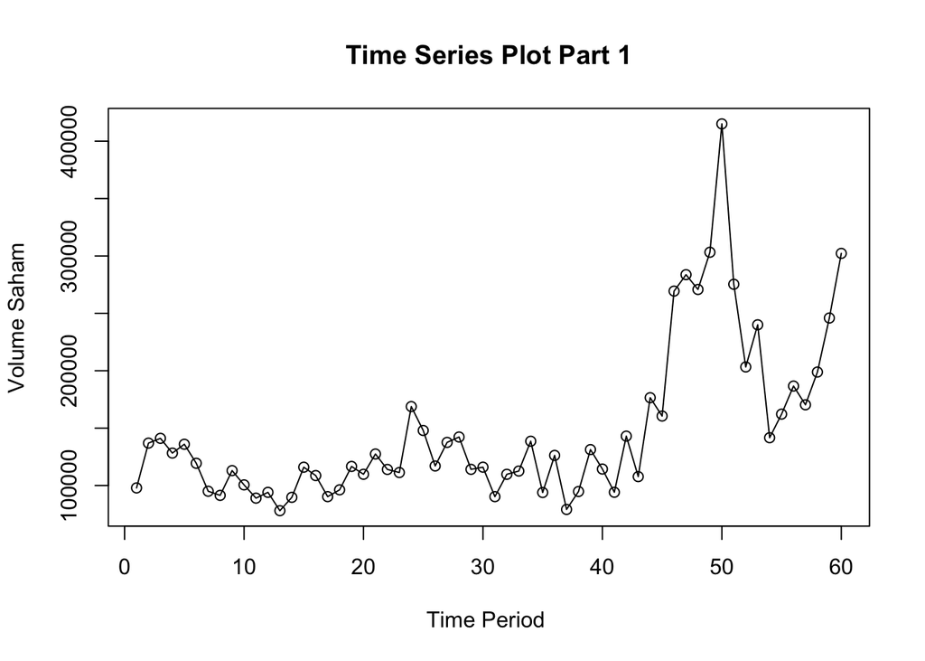

```r
ts.plot(databaru1, xlab="Time Period ", ylab="Volume Saham",
        main = "Time Series Plot Part 1")
points(databaru1)
```

Plot deret waktu di atas pada data partisi 1 menunjukkan bahwa data tidak stasioner dalam rataan, ditandai dengan data yang menyebar di sekitar nilai tengahnya yang bernilai 148104.1 dan juga tidak stasioner dalam ragam, ditandai dengan lebar pita yang cenderung tidak sama.

### Plot ACF

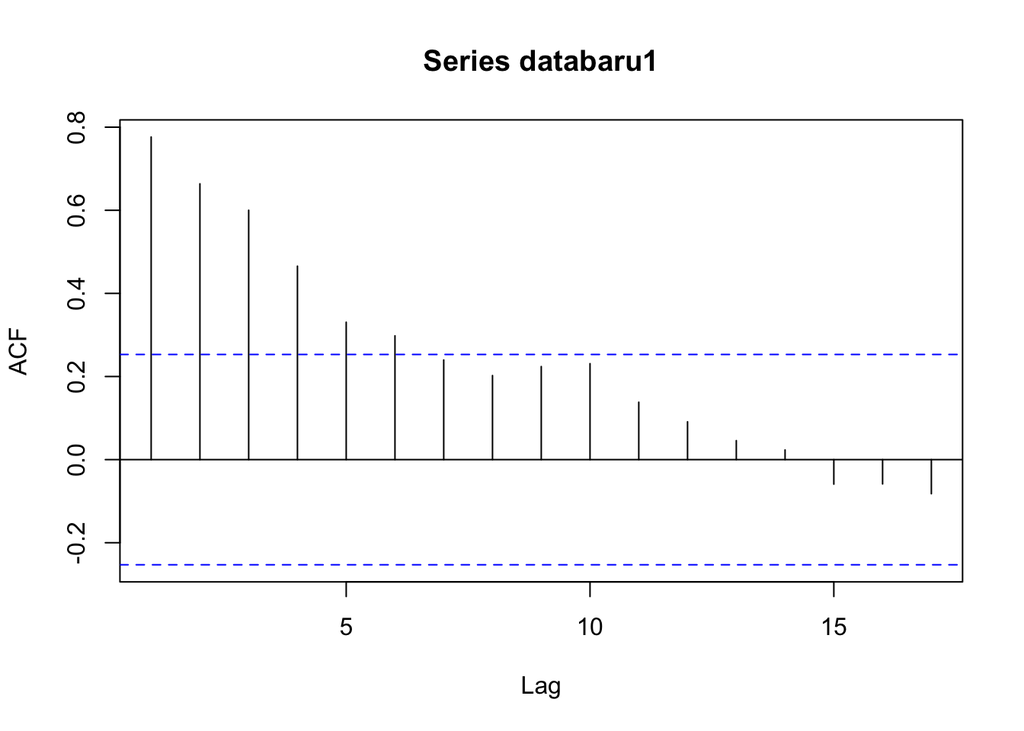

```r
acf(databaru1)
```

Berdasarkan plot ACF, terlihat bahwa plot ACF pada data partisi 1 tersebut cenderung *tails off* slowly maka data tersebut terindikasi tidak stasioner

### Uji ADF

```r
tseries::adf.test(databaru1)
```

```
##
##  Augmented Dickey-Fuller Test
##
## data:  databaru1
## Dickey-Fuller = -2.977, Lag order = 3, p-value = 0.1799
## alternative hypothesis: stationary
```

$H_0$ : Data tidak stasioner dalam rataan

$H_1$ : Data stasioner dalam rataan

Berdasarkan uji ADF tersebut, didapat *p-value* sebesar 0.1799 yang lebih besar dari taraf nyata 5% sehingga terima $H_0$ dan menandakan bahwa data tidak stasioner dalam rataan. Hal ini sesuai dengan hasil eksplorasi menggunakan plot time series dan plot ACF.

### Plot Box-Cox

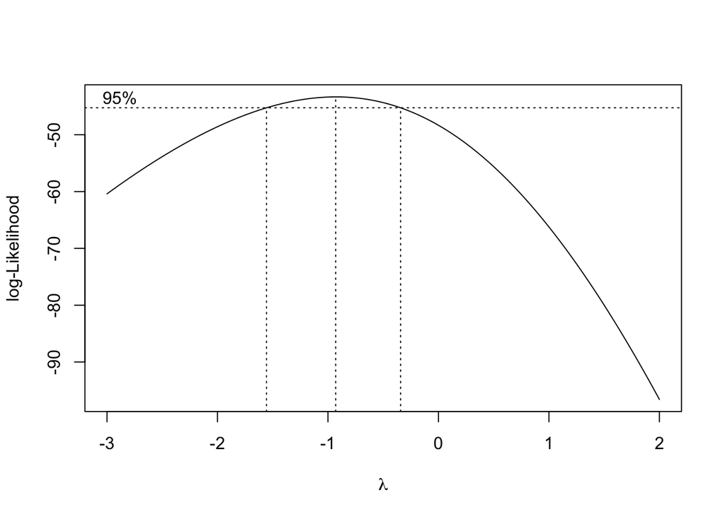

```r
index <- seq(1:60) #sebanyak row data
bc = boxcox(databaru1~index, lambda = seq(-3,2,by=0.01))
```

```r
#Nilai Rounded Lambda
lambda <- bc$x[which.max(bc$y)]
lambda
```

```
## [1] -0.93
```

```r
#SK
bc$x[bc$y > max(bc$y) - 1/2 * qchisq(.95,1)]
```

```
##   [1] -1.55 -1.54 -1.53 -1.52 -1.51 -1.50 -1.49 -1.48 -1.47 -1.46 -1.45 -1.44
##  [13] -1.43 -1.42 -1.41 -1.40 -1.39 -1.38 -1.37 -1.36 -1.35 -1.34 -1.33 -1.32
##  [25] -1.31 -1.30 -1.29 -1.28 -1.27 -1.26 -1.25 -1.24 -1.23 -1.22 -1.21 -1.20
##  [37] -1.19 -1.18 -1.17 -1.16 -1.15 -1.14 -1.13 -1.12 -1.11 -1.10 -1.09 -1.08
##  [49] -1.07 -1.06 -1.05 -1.04 -1.03 -1.02 -1.01 -1.00 -0.99 -0.98 -0.97 -0.96
##  [61] -0.95 -0.94 -0.93 -0.92 -0.91 -0.90 -0.89 -0.88 -0.87 -0.86 -0.85 -0.84
##  [73] -0.83 -0.82 -0.81 -0.80 -0.79 -0.78 -0.77 -0.76 -0.75 -0.74 -0.73 -0.72
##  [85] -0.71 -0.70 -0.69 -0.68 -0.67 -0.66 -0.65 -0.64 -0.63 -0.62 -0.61 -0.60
##  [97] -0.59 -0.58 -0.57 -0.56 -0.55 -0.54 -0.53 -0.52 -0.51 -0.50 -0.49 -0.48
## [109] -0.47 -0.46 -0.45 -0.44 -0.43 -0.42 -0.41 -0.40 -0.39 -0.38 -0.37 -0.36
## [121] -0.35
```

Gambar di atas menunjukkan nilai *rounded value* ($\lambda$) optimum sebesar **-0,93** dan pada selang kepercayaan 95% nilai memiliki batas bawah **-1,55** dan batas atas **-0,35**. Selang tersebut tidak memuat nilai 1 sehingga dapat dikatakan bahwa data tersebut **tidak stasioner dalam ragam**.

## Partisi Data Part 2

### Time Series

```r
databaru2 <- databaru.ts[1:105]
databaru2
```

```
##   [1]  97907 136954 141112 128263 135960 119400  95011  91423 113009 100552
##  [11]  89003  94061  78078  89697 115971 108673  90306  96246 116638 109811
##  [21] 127460 114011 111326 168797 147941 117029 137569 142273 114090 115989
##  [31]  90296 109775 112610 138593  93912 126237  79156  94791 131300 114330
##  [41]  94130 143031 107755 176515 160521 269396 283703 270791 303220 415074
##  [51] 275347 203298 240022 141638 162203 186676 170331 198852 245943 302241
##  [61] 257196 282210 238661 188754 184974 133077 203306 190500 178049 226767
##  [71] 206276 246509 293512 272166 300768 290020 284584 225371 400624 338713
##  [81] 307071 383301 228062 238175 164351 122322 143293 158484 137187 198152
##  [91] 206979 217089 242612 222994 415152 523856 472372 351919 386117 317816
## [101] 283957 438843 372062 466052 488726
```

```r
mean(databaru2)
```

```
## [1] 203002.2
```

```r
var(databaru2)
```

```
## [1] 11254516697
```

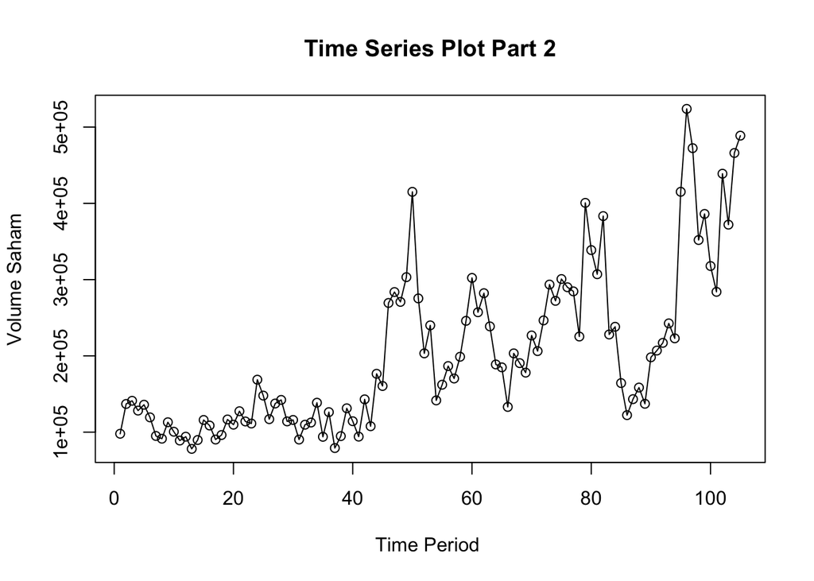

```r
ts.plot(databaru2, xlab="Time Period ", ylab="Volume Saham",
        main = "Time Series Plot Part 2")
points(databaru2)
```

Plot deret waktu di atas pada data partisi 2 menunjukkan bahwa data tidak stasioner dalam rataan, ditandai dengan data yang menyebar di sekitar nilai tengahnya yang bernilai 203002.2 dan juga tidak stasioner dalam ragam ditandai dengan lebar pita yang cenderung tidak sama.

### Plot ACF

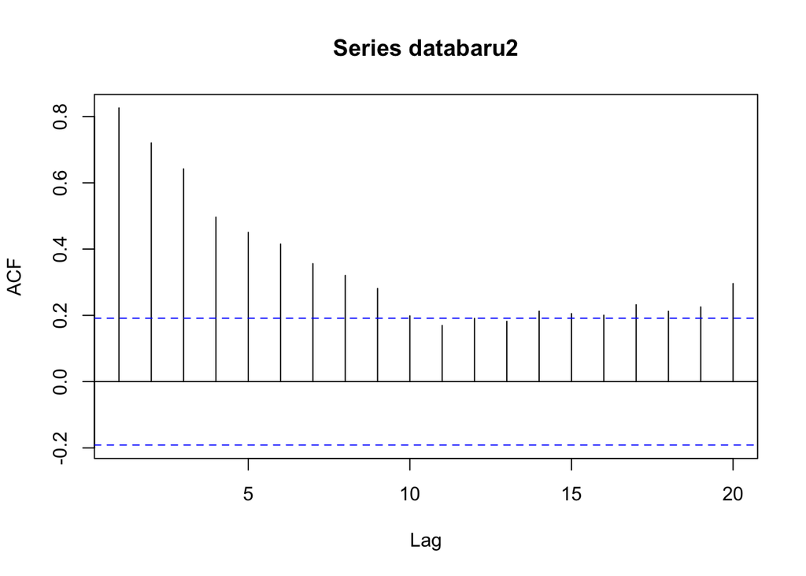

```r
acf(databaru2)
```

Berdasarkan plot ACF, terlihat bahwa plot ACF pada data partisi 2 tersebut cenderung *tails off* slowly maka data tersebut terindikasi tidak stasioner.

### Uji ADF

```r
tseries::adf.test(databaru2, k = 6)
```

```
##
##  Augmented Dickey-Fuller Test
##
## data:  databaru2
## Dickey-Fuller = -3.1183, Lag order = 6, p-value = 0.1129
## alternative hypothesis: stationary
```

$H_0$ : Data tidak stasioner dalam rataan

$H_1$ : Data stasioner dalam rataan

Berdasarkan uji ADF tersebut, didapat *p-value* sebesar 0.1129 yang lebih besar dari taraf nyata 5% sehingga terima $H_0$ dan menandakan bahwa data tidak stasioner dalam rataan. Hal ini sesuai dengan hasil eksplorasi menggunakan plot time series dan plot ACF.

### Plot Box-Cox

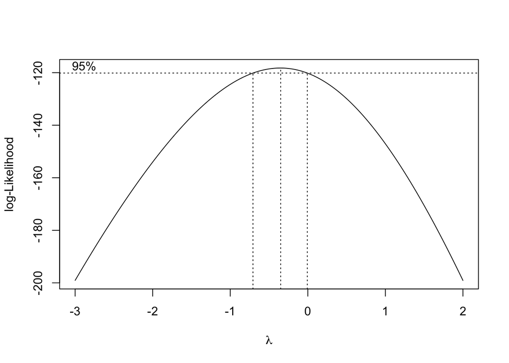

```r
index <- seq(1:105) #sebanyak row data
bc = boxcox(databaru2~index, lambda = seq(-3,2,by=0.01))
```

```r
#Nilai Rounded Lambda
lambda <- bc$x[which.max(bc$y)]
lambda
```

```
## [1] -0.35
```

```r
#SK
bc$x[bc$y > max(bc$y) - 1/2 * qchisq(.95,1)]
```

```
##  [1] -0.70 -0.69 -0.68 -0.67 -0.66 -0.65 -0.64 -0.63 -0.62 -0.61 -0.60 -0.59
## [13] -0.58 -0.57 -0.56 -0.55 -0.54 -0.53 -0.52 -0.51 -0.50 -0.49 -0.48 -0.47
## [25] -0.46 -0.45 -0.44 -0.43 -0.42 -0.41 -0.40 -0.39 -0.38 -0.37 -0.36 -0.35
## [37] -0.34 -0.33 -0.32 -0.31 -0.30 -0.29 -0.28 -0.27 -0.26 -0.25 -0.24 -0.23
## [49] -0.22 -0.21 -0.20 -0.19 -0.18 -0.17 -0.16 -0.15 -0.14 -0.13 -0.12 -0.11
## [61] -0.10 -0.09 -0.08 -0.07 -0.06 -0.05 -0.04 -0.03 -0.02 -0.01
```

Gambar di atas menunjukkan nilai *rounded value* ($\lambda$) optimum sebesar **-0,35** dan pada selang kepercayaan 95% nilai memiliki batas bawah **-0,70** dan batas atas **-0,01**. Selang tersebut tidak memuat nilai 1 sehingga dapat dikatakan bahwa data tersebut **tidak stasioner dalam ragam**.